# Linear Regression

March 11 2020

## Objectives

- Understand linear regression and describe a case study
- Compute and interpret coefficients in a linear regression analysis in R.
- Interpolate regression model in R to produce a raster layer.

## Science

What are we doing?

- Explain
- Predict

## Connections

Why is it windy in Iowa?

- Missouri sucks and Minnesota blows.
- No connection

Why are basements in Iowa full of cracks?

- Soils in Iowa contain high amounts of shrink-swell clays
- Connection

## Predictions and Predicting with a Function

Predictions

- None of us will report to work on Sunday
- The average price of a gallon of gas in the US will be $100.00 on January 1

Predicting with a function

- \[y= \beta_0 + \beta_1x + \epsilon\]

## Assumptions

- Linear
- Independent
- Homoscedastic
- Normal

## Interpreting the Linear Regression Model

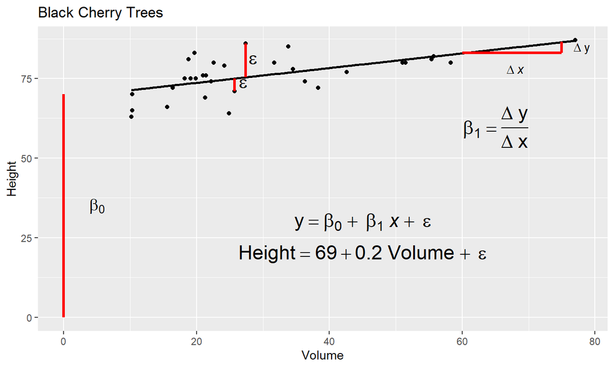

## Building the Linear Regression Model

- Ordinary Least Squares
- \[\beta_1= \frac{\sum(x_i - \bar x) (y_i - \bar y)} {\sum(x_i - \bar x)^2}\]
- \[\beta_0= \bar y - \beta_1 \times \bar x\]

## Examples

Wills et al., 2013

Carbon equivalent correction regression factor: \[OC_{dc}= 0.25 + 0.86(OC_{wc})\] where

\(OC_{dc}=\) organic carbon by dry combustion (%)

\(OC_{wc}=\) organic carbon by wet combustion (%)

## Examples

[figure not shown]

## Examples

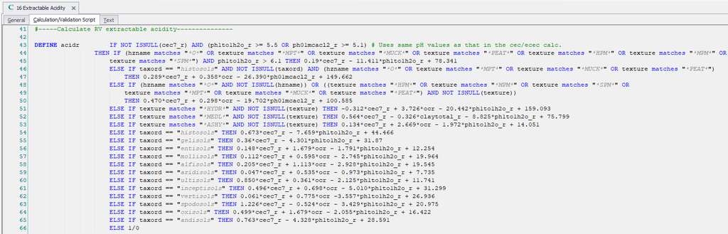

## Simple vs. Multiple Linear Regression

- Simple linear regression (SLR):  
  Y is predicted from **one** independent variable (\(x\))
- Multiple linear regression (MLR): Y is predicted from **two or more** independent variables (\(x_1,x_2,x_3...\))

## Assumptions

- Linear
- Independent
- Homoscedastic
- Normal

## Testing Model Assumptions

- Normality
  - Histograms
  - QQ plots
  - Residual plots
- Outliers
  - QQ plots
  - Box plots
- Multicollinearity
  - Correlation \(\geq0.7\) or \(\leq-0.7\) indicates highly correlated
  - Variance inflation factors
- Homoscedasticity
  - Residual plots

## Heteroscedasticity

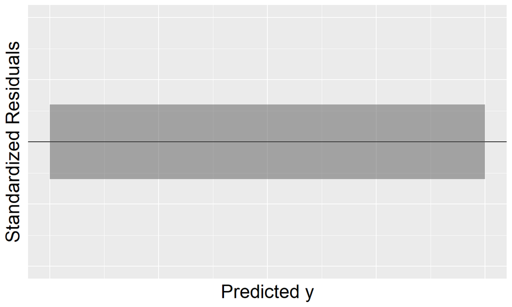

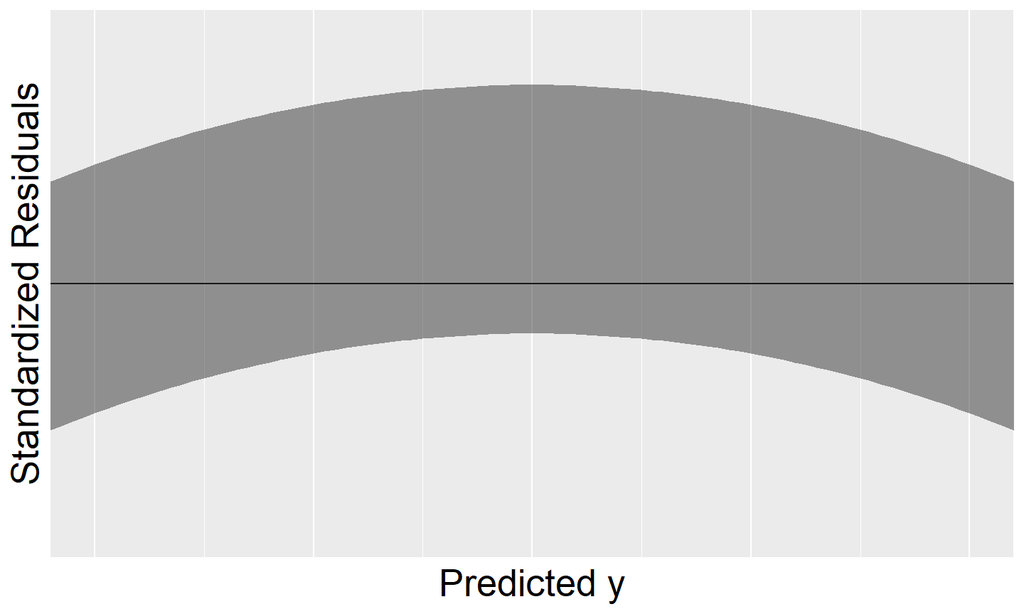

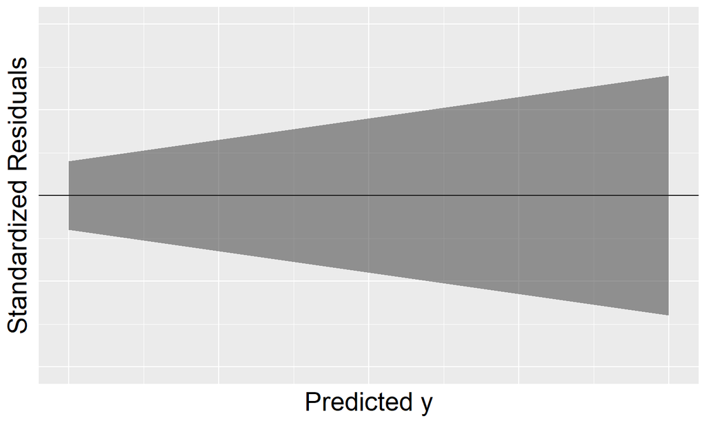

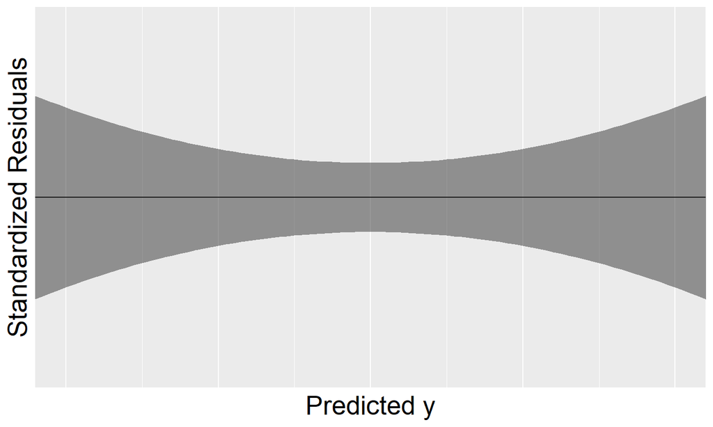

## Analysis of Residuals

- Heteroscedasticity
  - causes estimates of regression coefficients to be less precise
- Non-normality
  - compromises interpretability of significance tests of the regression coefficients
- Multicollinearity
  - over-estimates the variances of the regression coefficients
- Spatial Autocorrelation
  - results in an underestimation of the standard error of the estimates of the regression coefficients and a bias towards rejecting the \(H_0\) that the value of the coefficient is zero

## Interpreting Model Results

```r
summary(fit)
```

```
##
## Call:
## lm(formula = Height ~ Volume, data = d)
##
## Residuals:
##      Min       1Q   Median       3Q      Max
## -10.7777  -2.9722  -0.1515   2.0804  10.6426
##
...
```

## Interpreting Model Results

```r
summary(fit)
```

```
...
##
## Coefficients:
##             Estimate Std. Error t value Pr(>|t|)
## (Intercept) 69.00336    1.97443  34.949  < 2e-16 ***
## Volume       0.23190    0.05768   4.021 0.000378 ***
## ---
## Signif. codes:  0 '***' 0.001 '**' 0.01 '*' 0.05 '.' 0.1 ' ' 1
##
...
```

## Interpreting Model Results

```r
summary(fit)
```

```
...
##
## Residual standard error: 5.193 on 29 degrees of freedom
## Multiple R-squared:  0.3579, Adjusted R-squared:  0.3358
## F-statistic: 16.16 on 1 and 29 DF,  p-value: 0.0003784
...
```

## Diagnostic Plots

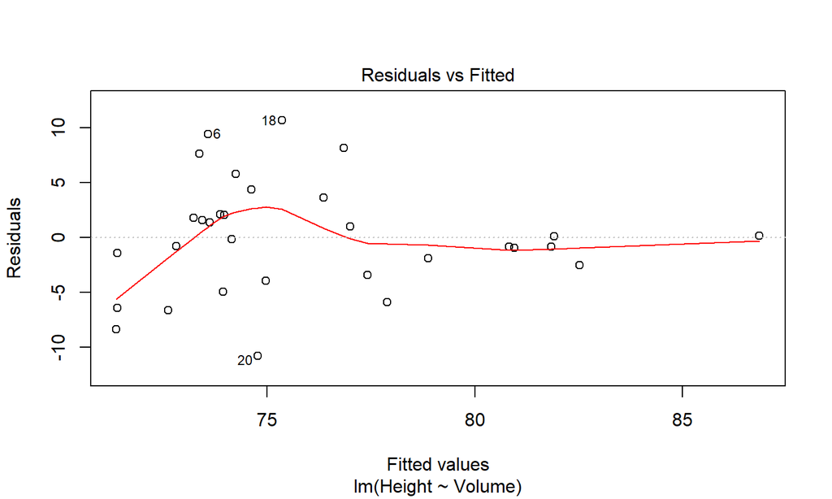

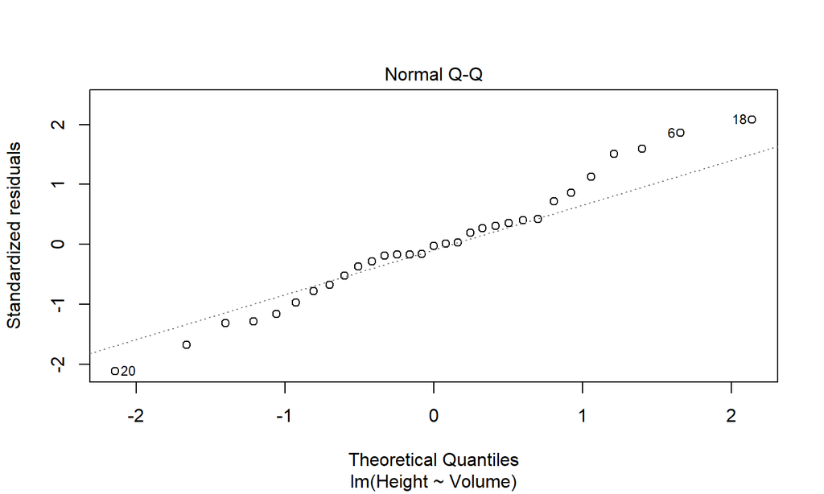

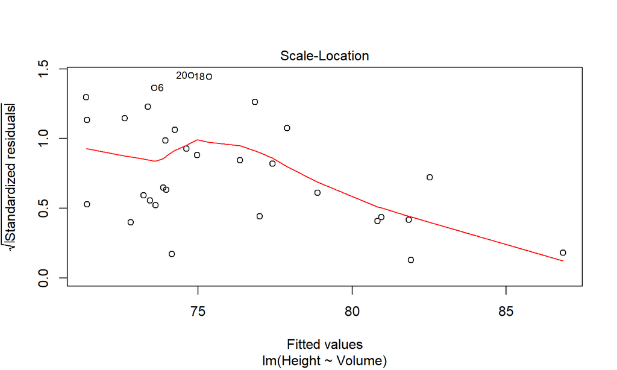

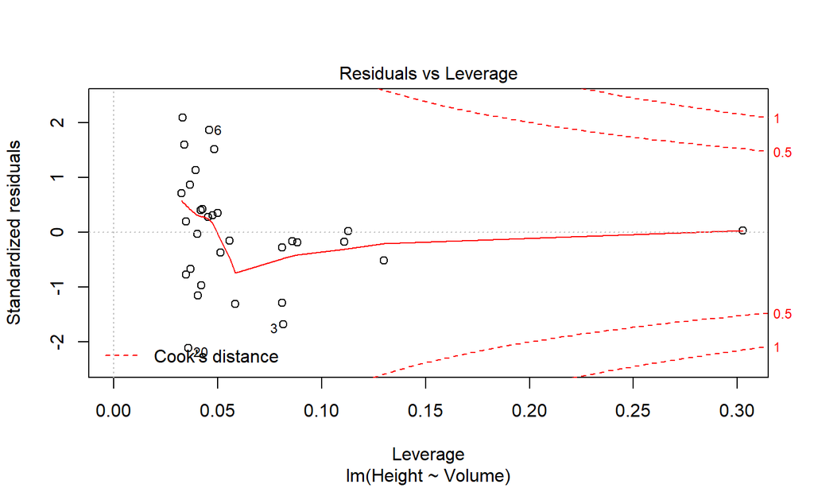

```r
plot(fit)
```

## Residuals vs Fitted

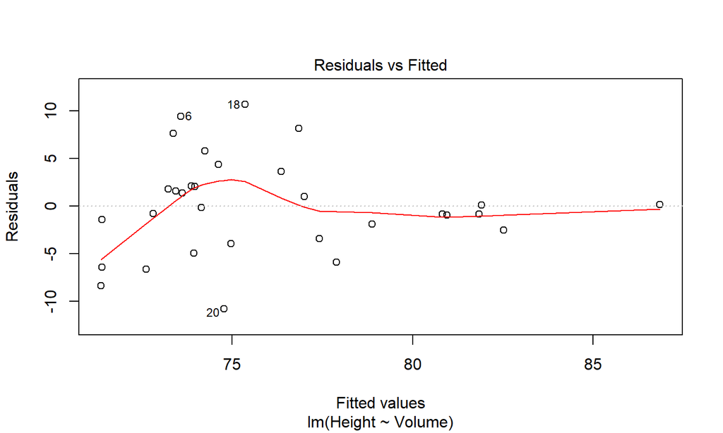

```r
plot(fit, 1)
```

## QQ Plot

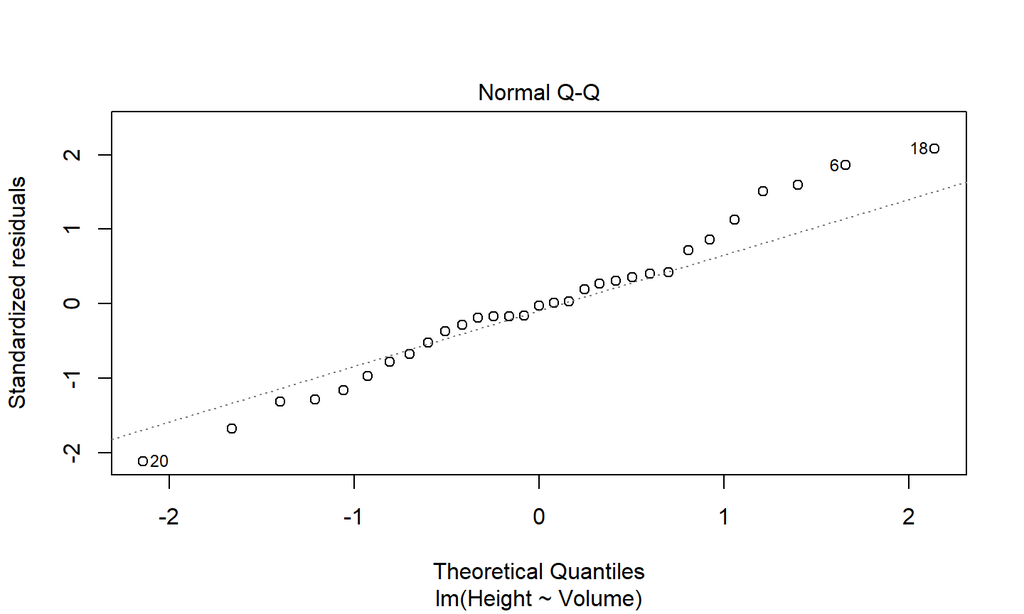

```r
plot(fit, 2)
```

## Spread-Location

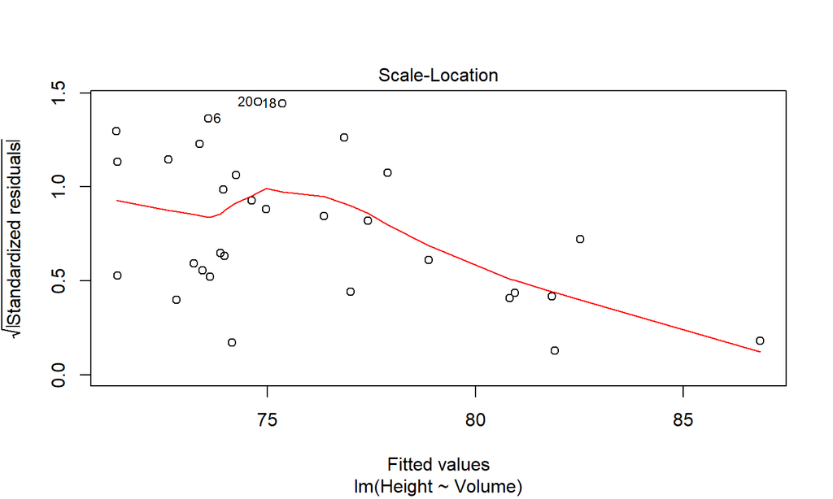

```r
plot(fit, 3)
```

## Leverage Plot

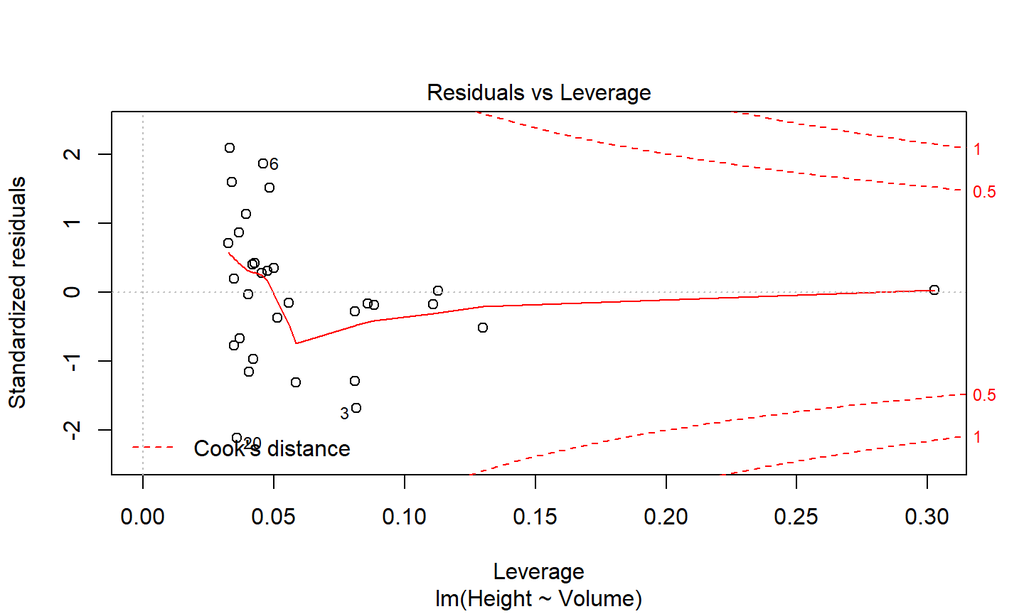

```r
plot(fit, 5)
```

## Exercise: Linear Regression

http://ncss-tech.github.io/stats_for_soil_survey/chapters/6_linear_models/6_Linear_models_v2.html

## Summary

- Linear regression models are intuitive, quick to execute, and easy to interpret, making them useful for NASIS calculations and pedotransfer functions.
- Due to the non-linear nature of environmental data, data transformations or deletions are often needed to meet model assumptions.
- Tacit knowledge is needed throughout model development.

## Linear Regression in R

\[lm(formula, data)\]

**formula** \(response \sim predictor_1+predictor_2+predictor_x\)  
**data** specifies the dataset

**summary()** detailed statistical summary  
**plot()** a series of diagnostic plots

```r
d <- trees
fit <- lm(Height ~ Volume, d)
summary(fit)
plot(fit)
```

## Linear Regression in R - Diagnostics Tests

**cor()** - correlation matrix

**hist()** - histogram

**vif()** - variance-inflation and generalized variance inflation factors for linear and generalized linear models (in car package)

```r
cor(d)
hist(d$Height)
library(car)
vif(fit)
```

## Other Types of Regression

**Step-wise regression** - typically used for exploratory data analysis or datasets with large sets of predictors; not recommended for modeling due to its unreliability

**Weighted least squares regression** - potentially useful when the homoscedasticity assumption is violated in OLS; gives more weight to observations with small error variance. WLS is not recommended unless the variance structure is known.

**Logistic regression** - useful when predicting a binary outcome from a set of continuous predictor variables.

## Review Questions

- What are the components of a simple linear regression equation?
- What is the main limitation of using linear regression?
- Can you think of other names for regression?
- Are more variables better?

## Additional Resources

Sum of Squares Regression: \(SSR = \sum(\hat{y}-\bar{y})\)

Sum of Squares Error \(SSE = \sum(y-\hat{y})\)

where

\(y=\) observed

\(\hat{y}=\) predicted

\(\bar{y}=\) population mean

## Additional Resources

Root Mean Square Error \(=\sqrt{MSE}\)

\(R^2=\frac{SSR}{SST}\)

\(R^2(adj)=1 - \big( \frac{N - 1}{N - K - 1}\big) \frac{SSE}{SST}\)

Residual Standard Error \(=\sqrt{\frac{SSE}{N - 2}}\)

\(t=\frac{\beta}{SE_\beta}\)

N = number of observations  
K = number of variables  
\(\beta\) = coefficient

## Additional Resources - ANOVA

| Source | SS | DF | MS | F |
| --- | --- | --- | --- | --- |
| Regression (or explained) | \(SSR\) | \(K\) | \(MSR = \frac{SSR}{K}\) | \(F=\frac{MSR}{MSE}\) |
| Error (or residual) | \(SSE\) | \(N-K-1\) | \(MSE = \frac{SSE}{(N-K-1)}\) |  |
| Total | \(SST\) | \(N-1\) | \(MST=\frac{SST}{(N-1)}\) |  |

An alternative formula for F, which is sometimes useful when the original data are not available (e.g. when reading someone else’s article) is  
\(F=\frac{R^2\times(N-K-1)}{(1-R^2)\times K}\)

where N = number of observations and K = number of variables

## References

Bishop, TFA, and AB McBratney. 2001. “A Comparison of Prediction Methods for the Creation of Field-Extent Soil Property Maps.” *Geoderma* 103 (1-2): 149–60.

Faraway, Julian J. 2002. “Practical Regression and Anova Using R.” University of Bath Bath.

Holland, Steven. 2011. “Data Analysis in Geosciences.” 2011. http://strata.uga.edu/6370/rtips/regressionPlots.html.

Seybold, Cathy A, Paul R Finnell, and Moustafa A Elrashidi. 2009. “Estimating Total Acidity from Soil Properties Using Linear Models.” *Soil Science* 174 (2): 88–93.

Whittingham, Mark J, Philip A Stephens, Richard B Bradbury, and Robert P Freckleton. 2006. “Why Do We Still Use Stepwise Modelling in Ecology and Behaviour?” *Journal of Animal Ecology* 75 (5): 1182–9.

Wills, Skye, Cathy Seybold, Joe Chiaretti, Cleiton Sequeira, and Larry West. 2013. “Quantifying Tacit Knowledge About Soil Organic Carbon Stocks Using Soil Taxa and Official Soil Series Descriptions.” *Soil Science Society of America Journal* 77 (5): 1711–23.